# Risk Factor Analysis

## Outcome Variable

**Outcome Variable:** pers_wasted624

## Predictor Variables

**Intervention Variable:** ever_underweight06

**Adjustment Set:**

- sex
- arm
- brthmon
- vagbrth
- single
- W_mage
- W_mhtcm
- W_mwtkg
- W_mbmi
- W_meducyrs
- W_feducyrs
- W_parity
- delta_brthmon
- delta_vagbrth
- delta_single
- delta_W_mage
- delta_W_mhtcm
- delta_W_mwtkg
- delta_W_mbmi
- delta_W_meducyrs
- delta_W_feducyrs
- delta_W_parity

## Stratifying Variables

The analysis was stratified on these variable(s):

- studyid
- country

## Data Summary

| studyid | country | ever_underweight06 | pers_wasted624 | n_cell | n |
| --- | --- | --- | --- | --- | --- |
| CMC-V-BCS-2002 | INDIA | 0 | 0 | 186 | 373 |
| CMC-V-BCS-2002 | INDIA | 0 | 1 | 4 | 373 |
| CMC-V-BCS-2002 | INDIA | 1 | 0 | 159 | 373 |
| CMC-V-BCS-2002 | INDIA | 1 | 1 | 24 | 373 |
| CMIN | BANGLADESH | 0 | 0 | 118 | 252 |
| CMIN | BANGLADESH | 0 | 1 | 1 | 252 |
| CMIN | BANGLADESH | 1 | 0 | 109 | 252 |
| CMIN | BANGLADESH | 1 | 1 | 24 | 252 |
| COHORTS | GUATEMALA | 0 | 0 | 731 | 1023 |
| COHORTS | GUATEMALA | 0 | 1 | 4 | 1023 |
| COHORTS | GUATEMALA | 1 | 0 | 251 | 1023 |
| COHORTS | GUATEMALA | 1 | 1 | 37 | 1023 |
| COHORTS | INDIA | 0 | 0 | 4367 | 6897 |
| COHORTS | INDIA | 0 | 1 | 112 | 6897 |
| COHORTS | INDIA | 1 | 0 | 1759 | 6897 |
| COHORTS | INDIA | 1 | 1 | 659 | 6897 |
| COHORTS | PHILIPPINES | 0 | 0 | 2080 | 2809 |
| COHORTS | PHILIPPINES | 0 | 1 | 73 | 2809 |
| COHORTS | PHILIPPINES | 1 | 0 | 503 | 2809 |
| COHORTS | PHILIPPINES | 1 | 1 | 153 | 2809 |
| CONTENT | PERU | 0 | 0 | 207 | 215 |
| CONTENT | PERU | 0 | 1 | 0 | 215 |
| CONTENT | PERU | 1 | 0 | 8 | 215 |
| CONTENT | PERU | 1 | 1 | 0 | 215 |
| EE | PAKISTAN | 0 | 0 | 101 | 374 |
| EE | PAKISTAN | 0 | 1 | 1 | 374 |
| EE | PAKISTAN | 1 | 0 | 224 | 374 |
| EE | PAKISTAN | 1 | 1 | 48 | 374 |
| GMS-Nepal | NEPAL | 0 | 0 | 302 | 590 |
| GMS-Nepal | NEPAL | 0 | 1 | 17 | 590 |

[output cut: 90 more lines]

The following strata were considered:

- studyid: CMC-V-BCS-2002, country: INDIA
- studyid: CMIN, country: BANGLADESH
- studyid: COHORTS, country: GUATEMALA
- studyid: COHORTS, country: INDIA
- studyid: COHORTS, country: PHILIPPINES
- studyid: CONTENT, country: PERU
- studyid: EE, country: PAKISTAN
- studyid: GMS-Nepal, country: NEPAL
- studyid: Guatemala BSC, country: GUATEMALA
- studyid: IRC, country: INDIA
- studyid: JiVitA-3, country: BANGLADESH
- studyid: JiVitA-4, country: BANGLADESH
- studyid: Keneba, country: GAMBIA
- studyid: LCNI-5, country: MALAWI
- studyid: MAL-ED, country: BANGLADESH
- studyid: MAL-ED, country: BRAZIL
- studyid: MAL-ED, country: INDIA
- studyid: MAL-ED, country: NEPAL
- studyid: MAL-ED, country: PERU
- studyid: MAL-ED, country: SOUTH AFRICA
- studyid: MAL-ED, country: TANZANIA, UNITED REPUBLIC OF
- studyid: NIH-Birth, country: BANGLADESH
- studyid: NIH-Crypto, country: BANGLADESH
- studyid: PROBIT, country: BELARUS
- studyid: PROVIDE, country: BANGLADESH
- studyid: ResPak, country: PAKISTAN
- studyid: SAS-CompFeed, country: INDIA
- studyid: SAS-FoodSuppl, country: INDIA
- studyid: TanzaniaChild2, country: TANZANIA, UNITED REPUBLIC OF
- studyid: ZVITAMBO, country: ZIMBABWE

### Dropped Strata

Some strata were dropped due to rare outcomes:

- studyid: CMC-V-BCS-2002, country: INDIA
- studyid: CMIN, country: BANGLADESH
- studyid: COHORTS, country: GUATEMALA
- studyid: CONTENT, country: PERU
- studyid: EE, country: PAKISTAN
- studyid: Guatemala BSC, country: GUATEMALA
- studyid: LCNI-5, country: MALAWI
- studyid: MAL-ED, country: BANGLADESH
- studyid: MAL-ED, country: BRAZIL
- studyid: MAL-ED, country: INDIA
- studyid: MAL-ED, country: NEPAL
- studyid: MAL-ED, country: PERU
- studyid: MAL-ED, country: SOUTH AFRICA
- studyid: MAL-ED, country: TANZANIA, UNITED REPUBLIC OF

## Methods Detail

We’re interested in the causal parameters $E[Y_a]$ for all values of $a \in \mathcal{A}$. These parameters represent the mean outcome if, possibly contrary to fact, we intervened to set all units to have $A=a$. Under the randomization and positivity assumptions, these are identified by the statistical parameters $\psi_a=E_W[E_{Y|A,W}(Y|A=a,W)]$. In addition, we’re interested in the mean of $Y$, $E[Y]$ under no intervention (the observed mean). We will estimate these parameters by using SuperLearner to fit the relevant likelihood factors – $E_{Y|A,W}(Y|A=a,W)$ and $p(A=a|W)$, and then updating our likelihood fit using a joint TMLE.

For unadjusted analyses ($W=\{\}$), initial likelihoods were estimated using Lrnr_glm to estimate the simple $E(Y|A)$ and Lrnr_mean to estimate $p(A)$. For adjusted analyses, a small library containing Lrnr_glmnet, Lrnr_xgboost, and Lrnr_mean was used.

Having estimated these parameters, we will then use the delta method to estimate relative risks and attributable risks relative to a prespecified baseline level of $A$.

# Results Detail

## Results Plots

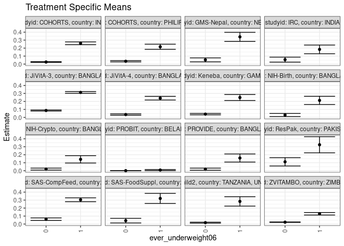

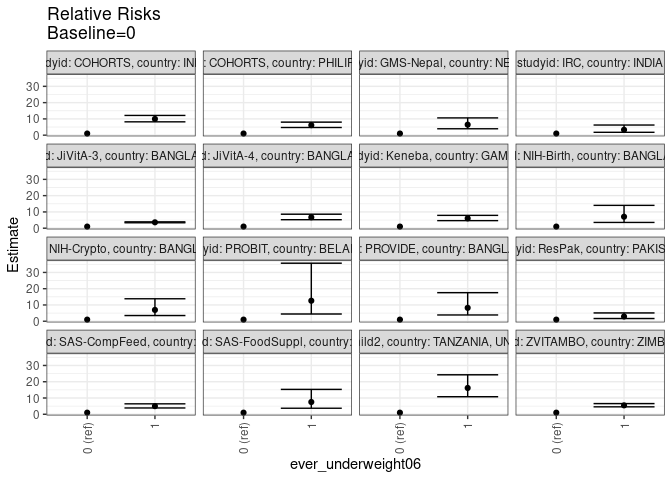

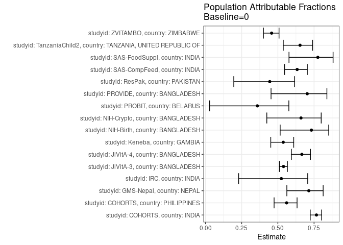

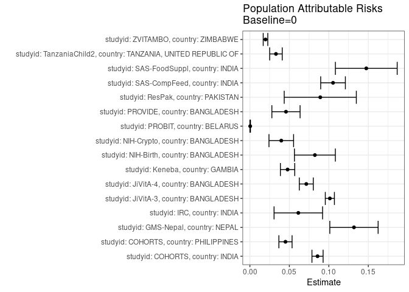

## Results Table

### Parameter: TSM

| studyid | country | intervention_level | baseline_level | estimate | ci_lower | ci_upper |
| --- | --- | --- | --- | --- | --- | --- |
| COHORTS | INDIA | 0 | NA | 0.0261076 | 0.0213035 | 0.0309116 |
| COHORTS | INDIA | 1 | NA | 0.2603191 | 0.2425619 | 0.2780764 |
| COHORTS | PHILIPPINES | 0 | NA | 0.0353730 | 0.0275240 | 0.0432219 |
| COHORTS | PHILIPPINES | 1 | NA | 0.2168021 | 0.1844558 | 0.2491484 |
| GMS-Nepal | NEPAL | 0 | NA | 0.0529088 | 0.0281330 | 0.0776846 |
| GMS-Nepal | NEPAL | 1 | NA | 0.3410877 | 0.2843286 | 0.3978468 |
| IRC | INDIA | 0 | NA | 0.0557271 | 0.0243731 | 0.0870811 |
| IRC | INDIA | 1 | NA | 0.1839781 | 0.1296664 | 0.2382898 |
| JiVitA-3 | BANGLADESH | 0 | NA | 0.0866210 | 0.0801745 | 0.0930675 |
| JiVitA-3 | BANGLADESH | 1 | NA | 0.3126384 | 0.3013783 | 0.3238986 |
| JiVitA-4 | BANGLADESH | 0 | NA | 0.0359050 | 0.0275207 | 0.0442893 |
| JiVitA-4 | BANGLADESH | 1 | NA | 0.2406768 | 0.2177617 | 0.2635920 |
| Keneba | GAMBIA | 0 | NA | 0.0411615 | 0.0322504 | 0.0500727 |
| Keneba | GAMBIA | 1 | NA | 0.2490225 | 0.2113007 | 0.2867443 |
| NIH-Birth | BANGLADESH | 0 | NA | 0.0302013 | 0.0107524 | 0.0496502 |
| NIH-Birth | BANGLADESH | 1 | NA | 0.2131148 | 0.1616847 | 0.2645448 |
| NIH-Crypto | BANGLADESH | 0 | NA | 0.0205055 | 0.0081272 | 0.0328838 |
| NIH-Crypto | BANGLADESH | 1 | NA | 0.1426235 | 0.0965059 | 0.1887411 |
| PROBIT | BELARUS | 0 | NA | 0.0006963 | 0.0002033 | 0.0011893 |
| PROBIT | BELARUS | 1 | NA | 0.0087719 | 0.0017865 | 0.0157574 |
| PROVIDE | BANGLADESH | 0 | NA | 0.0193237 | 0.0060525 | 0.0325948 |
| PROVIDE | BANGLADESH | 1 | NA | 0.1592040 | 0.1085836 | 0.2098244 |
| ResPak | PAKISTAN | 0 | NA | 0.1116933 | 0.0598236 | 0.1635629 |
| ResPak | PAKISTAN | 1 | NA | 0.3250899 | 0.2239914 | 0.4261885 |
| SAS-CompFeed | INDIA | 0 | NA | 0.0609899 | 0.0452404 | 0.0767395 |
| SAS-CompFeed | INDIA | 1 | NA | 0.3040240 | 0.2799201 | 0.3281280 |
| SAS-FoodSuppl | INDIA | 0 | NA | 0.0425532 | 0.0136640 | 0.0714424 |
| SAS-FoodSuppl | INDIA | 1 | NA | 0.3207547 | 0.2578442 | 0.3836653 |
| TanzaniaChild2 | TANZANIA, UNITED REPUBLIC OF | 0 | NA | 0.0175328 | 0.0114319 | 0.0236336 |
| TanzaniaChild2 | TANZANIA, UNITED REPUBLIC OF | 1 | NA | 0.2834505 | 0.2246221 | 0.3422790 |
| ZVITAMBO | ZIMBABWE | 0 | NA | 0.0235063 | 0.0203662 | 0.0266464 |
| ZVITAMBO | ZIMBABWE | 1 | NA | 0.1287058 | 0.1132193 | 0.1441923 |

### Parameter: E(Y)

| studyid | country | intervention_level | baseline_level | estimate | ci_lower | ci_upper |
| --- | --- | --- | --- | --- | --- | --- |
| COHORTS | INDIA | NA | NA | 0.1117877 | 0.1043506 | 0.1192249 |
| COHORTS | PHILIPPINES | NA | NA | 0.0804557 | 0.0703953 | 0.0905161 |
| GMS-Nepal | NEPAL | NA | NA | 0.1847458 | 0.1534039 | 0.2160876 |
| IRC | INDIA | NA | NA | 0.1170732 | 0.0859146 | 0.1482317 |
| JiVitA-3 | BANGLADESH | NA | NA | 0.1879125 | 0.1813641 | 0.1944608 |
| JiVitA-4 | BANGLADESH | NA | NA | 0.1073532 | 0.0971813 | 0.1175251 |
| Keneba | GAMBIA | NA | NA | 0.0888980 | 0.0776057 | 0.1001903 |
| NIH-Birth | BANGLADESH | NA | NA | 0.1125461 | 0.0859151 | 0.1391771 |
| NIH-Crypto | BANGLADESH | NA | NA | 0.0602740 | 0.0429977 | 0.0775502 |
| PROBIT | BELARUS | NA | NA | 0.0010846 | 0.0004977 | 0.0016715 |
| PROVIDE | BANGLADESH | NA | NA | 0.0650407 | 0.0455353 | 0.0845460 |
| ResPak | PAKISTAN | NA | NA | 0.2008547 | 0.1494120 | 0.2522974 |
| SAS-CompFeed | INDIA | NA | NA | 0.1663067 | 0.1478935 | 0.1847199 |
| SAS-FoodSuppl | INDIA | NA | NA | 0.1900000 | 0.1515071 | 0.2284929 |
| TanzaniaChild2 | TANZANIA, UNITED REPUBLIC OF | NA | NA | 0.0505451 | 0.0409848 | 0.0601054 |
| ZVITAMBO | ZIMBABWE | NA | NA | 0.0432772 | 0.0394419 | 0.0471125 |

### Parameter: RR

| studyid | country | intervention_level | baseline_level | estimate | ci_lower | ci_upper |
| --- | --- | --- | --- | --- | --- | --- |
| COHORTS | INDIA | 0 | 0 | 1.000000 | 1.000000 | 1.000000 |
| COHORTS | INDIA | 1 | 0 | 9.971020 | 8.195232 | 12.131596 |
| COHORTS | PHILIPPINES | 0 | 0 | 1.000000 | 1.000000 | 1.000000 |
| COHORTS | PHILIPPINES | 1 | 0 | 6.129037 | 4.694089 | 8.002636 |
| GMS-Nepal | NEPAL | 0 | 0 | 1.000000 | 1.000000 | 1.000000 |
| GMS-Nepal | NEPAL | 1 | 0 | 6.446713 | 3.923462 | 10.592715 |
| IRC | INDIA | 0 | 0 | 1.000000 | 1.000000 | 1.000000 |
| IRC | INDIA | 1 | 0 | 3.301411 | 1.750281 | 6.227180 |
| JiVitA-3 | BANGLADESH | 0 | 0 | 1.000000 | 1.000000 | 1.000000 |
| JiVitA-3 | BANGLADESH | 1 | 0 | 3.609267 | 3.328889 | 3.913261 |
| JiVitA-4 | BANGLADESH | 0 | 0 | 1.000000 | 1.000000 | 1.000000 |
| JiVitA-4 | BANGLADESH | 1 | 0 | 6.703161 | 5.220033 | 8.607678 |
| Keneba | GAMBIA | 0 | 0 | 1.000000 | 1.000000 | 1.000000 |
| Keneba | GAMBIA | 1 | 0 | 6.049881 | 4.645255 | 7.879236 |
| NIH-Birth | BANGLADESH | 0 | 0 | 1.000000 | 1.000000 | 1.000000 |
| NIH-Birth | BANGLADESH | 1 | 0 | 7.056466 | 3.547479 | 14.036366 |
| NIH-Crypto | BANGLADESH | 0 | 0 | 1.000000 | 1.000000 | 1.000000 |
| NIH-Crypto | BANGLADESH | 1 | 0 | 6.955370 | 3.506329 | 13.797102 |
| PROBIT | BELARUS | 0 | 0 | 1.000000 | 1.000000 | 1.000000 |
| PROBIT | BELARUS | 1 | 0 | 12.598086 | 4.450502 | 35.661544 |
| PROVIDE | BANGLADESH | 0 | 0 | 1.000000 | 1.000000 | 1.000000 |
| PROVIDE | BANGLADESH | 1 | 0 | 8.238806 | 3.865305 | 17.560819 |
| ResPak | PAKISTAN | 0 | 0 | 1.000000 | 1.000000 | 1.000000 |
| ResPak | PAKISTAN | 1 | 0 | 2.910560 | 1.661287 | 5.099276 |
| SAS-CompFeed | INDIA | 0 | 0 | 1.000000 | 1.000000 | 1.000000 |
| SAS-CompFeed | INDIA | 1 | 0 | 4.984823 | 3.878352 | 6.406964 |
| SAS-FoodSuppl | INDIA | 0 | 0 | 1.000000 | 1.000000 | 1.000000 |
| SAS-FoodSuppl | INDIA | 1 | 0 | 7.537736 | 3.718280 | 15.280578 |
| TanzaniaChild2 | TANZANIA, UNITED REPUBLIC OF | 0 | 0 | 1.000000 | 1.000000 | 1.000000 |
| TanzaniaChild2 | TANZANIA, UNITED REPUBLIC OF | 1 | 0 | 16.166904 | 10.777038 | 24.252375 |
| ZVITAMBO | ZIMBABWE | 0 | 0 | 1.000000 | 1.000000 | 1.000000 |
| ZVITAMBO | ZIMBABWE | 1 | 0 | 5.475376 | 4.574884 | 6.553114 |

### Parameter: PAR

| studyid | country | intervention_level | baseline_level | estimate | ci_lower | ci_upper |
| --- | --- | --- | --- | --- | --- | --- |
| COHORTS | INDIA | 0 | NA | 0.0856802 | 0.0786120 | 0.0927483 |
| COHORTS | PHILIPPINES | 0 | NA | 0.0450827 | 0.0367206 | 0.0534449 |
| GMS-Nepal | NEPAL | 0 | NA | 0.1318370 | 0.1012406 | 0.1624333 |
| IRC | INDIA | 0 | NA | 0.0613461 | 0.0306215 | 0.0920706 |
| JiVitA-3 | BANGLADESH | 0 | NA | 0.1012914 | 0.0955246 | 0.1070582 |
| JiVitA-4 | BANGLADESH | 0 | NA | 0.0714482 | 0.0626053 | 0.0802912 |
| Keneba | GAMBIA | 0 | NA | 0.0477364 | 0.0386454 | 0.0568275 |
| NIH-Birth | BANGLADESH | 0 | NA | 0.0823448 | 0.0564310 | 0.1082586 |
| NIH-Crypto | BANGLADESH | 0 | NA | 0.0397685 | 0.0241704 | 0.0553665 |
| PROBIT | BELARUS | 0 | NA | 0.0003883 | 0.0000456 | 0.0007310 |
| PROVIDE | BANGLADESH | 0 | NA | 0.0457170 | 0.0278436 | 0.0635904 |
| ResPak | PAKISTAN | 0 | NA | 0.0891614 | 0.0434884 | 0.1348345 |
| SAS-CompFeed | INDIA | 0 | NA | 0.1053168 | 0.0896826 | 0.1209509 |
| SAS-FoodSuppl | INDIA | 0 | NA | 0.1474468 | 0.1083088 | 0.1865848 |
| TanzaniaChild2 | TANZANIA, UNITED REPUBLIC OF | 0 | NA | 0.0330123 | 0.0250635 | 0.0409612 |
| ZVITAMBO | ZIMBABWE | 0 | NA | 0.0197709 | 0.0168752 | 0.0226667 |

### Parameter: PAF

| studyid | country | intervention_level | baseline_level | estimate | ci_lower | ci_upper |
| --- | --- | --- | --- | --- | --- | --- |
| COHORTS | INDIA | 0 | NA | 0.7664540 | 0.7234672 | 0.8027586 |
| COHORTS | PHILIPPINES | 0 | NA | 0.5603424 | 0.4738813 | 0.6325947 |
| GMS-Nepal | NEPAL | 0 | NA | 0.7136131 | 0.5619899 | 0.8127498 |
| IRC | INDIA | 0 | NA | 0.5239977 | 0.2289902 | 0.7061280 |
| JiVitA-3 | BANGLADESH | 0 | NA | 0.5390352 | 0.5104959 | 0.5659106 |
| JiVitA-4 | BANGLADESH | 0 | NA | 0.6655436 | 0.5928167 | 0.7252807 |
| Keneba | GAMBIA | 0 | NA | 0.5369800 | 0.4509525 | 0.6095282 |
| NIH-Birth | BANGLADESH | 0 | NA | 0.7316536 | 0.5158152 | 0.8512763 |
| NIH-Crypto | BANGLADESH | 0 | NA | 0.6597948 | 0.4236252 | 0.7991939 |
| PROBIT | BELARUS | 0 | NA | 0.3580200 | 0.0283979 | 0.5758157 |
| PROVIDE | BANGLADESH | 0 | NA | 0.7028986 | 0.4528294 | 0.8386805 |
| ResPak | PAKISTAN | 0 | NA | 0.4439102 | 0.1955230 | 0.6156063 |
| SAS-CompFeed | INDIA | 0 | NA | 0.6332683 | 0.5464359 | 0.7034772 |
| SAS-FoodSuppl | INDIA | 0 | NA | 0.7760358 | 0.5768128 | 0.8814710 |
| TanzaniaChild2 | TANZANIA, UNITED REPUBLIC OF | 0 | NA | 0.6531263 | 0.5372947 | 0.7399611 |
| ZVITAMBO | ZIMBABWE | 0 | NA | 0.4568439 | 0.4003537 | 0.5080123 |